# Performance of the bit package

Dr. Jens Oehlschlägel

2025-03-04

## A performance example

Before we measure performance of the main functionality of the package, note that something simple as ‘(a:b)[-i]’ can and has been accelerated in this package:

```r
a <- 1L
b <- 1e7L
i <- sample(a:b, 1e3)
x <- c(
  R = median(microbenchmark((a:b)[-i], times=times)$time),
  bit = median(microbenchmark(bit_rangediff(c(a, b), i), times=times)$time),
  merge = median(microbenchmark(merge_rangediff(c(a, b), bit_sort(i)), times=times)$time)
)
knitr::kable(as.data.frame(as.list(x / x["R"] * 100)), caption="% of time relative to R", digits=1)
```

% of time relative to R

| R | bit | merge |
| --- | --- | --- |
| 100 | 26.9 | 30.4 |

The vignette is compiled with the following performance settings: 5 replications with domain size small 1000 and big 10^{6}, sample size small 1000 and big 10^{6}.

## Boolean data types

> “A designer knows he has achieved perfection not when there is nothing left to add, but when there is nothing left to take away.” “Il semble que la perfection soit atteinte non quand il n’y a plus rien à ajouter, mais quand il n’y a plus rien à retrancher” (Antoine de St. Exupery, Terre des Hommes (Gallimard, 1939), p. 60.)

We compare memory consumption (n=1e+06) and runtime (median of 5 replications) of the different `booltype`s for the following filter scenarios:

```r
knitr::kable(
  data.frame(
    coin="random 50%",
    often="random 99%",
    rare="random 1%",
    chunk="contiguous chunk of 5%"
  ),
  caption="selection characteristic"
)
```

selection characteristic

| coin | often | rare | chunk |
| --- | --- | --- | --- |
| random 50% | random 99% | random 1% | contiguous chunk of 5% |

```r
# nolint end: strings_as_factors_linter.
```

There are substantial savings in skewed filter situations:

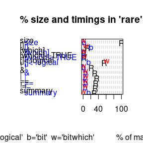

% size and execution time for bit (b) and bitwhich (w) relative to logical (R) in the ‘rare’ scenario

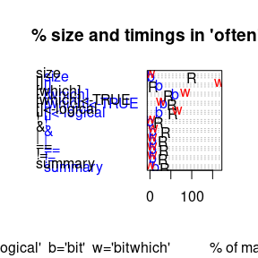

% size and execution time for bit (b) and bitwhich (w) relative to logical (R) in the ‘often’ scenario

Even in non-skewed situations the new booltypes are competitive:

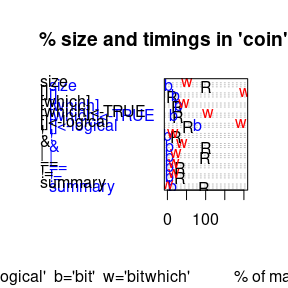

% size and execution time for bit (b) and bitwhich (w) relative to logical (R) in the ‘coin’ scenario

Detailed tables follow.

### % memory consumption of filter

% bytes of logical

|  | coin | often | rare | chunk |
| --- | --- | --- | --- | --- |
| logical | 100.0 | 100.0 | 100.0 | 100.0 |
| bit | 3.2 | 3.2 | 3.2 | 3.2 |
| bitwhich | 50.0 | 1.0 | 1.0 | 5.0 |
| which | 50.0 | 99.0 | 1.0 | 5.0 |
| ri | NA | NA | NA | 0.0 |

### % time extracting

% time of logical

|  | coin | often | rare | chunk |
| --- | --- | --- | --- | --- |
| logical | 11.9 | 6.7 | 10.9 | NA |
| bit | 21.1 | 21.1 | 20.8 | NA |
| bitwhich | 201.8 | 165.5 | 7.7 | NA |
| which | NA | NA | NA | NA |
| ri | NA | NA | NA | NA |

### % time assigning

% time of logical

|  | coin | often | rare | chunk |
| --- | --- | --- | --- | --- |
| logical | 54.0 | 53.8 | 54.6 | NA |
| bit | 79.9 | 20.7 | 14.4 | NA |
| bitwhich | 191.5 | 65.3 | 61.7 | NA |
| which | NA | NA | NA | NA |
| ri | NA | NA | NA | NA |

### % time subscripting with ‘which’

% time of logical

|  | coin | often | rare | chunk |
| --- | --- | --- | --- | --- |
| logical | 24.3 | 44.8 | 1.7 | NA |
| bit | 28.8 | 60.6 | 1.1 | NA |
| bitwhich | 42.4 | 84.7 | 2.3 | NA |
| which | NA | NA | NA | NA |
| ri | NA | NA | NA | NA |

### % time assigning with ‘which’

% time of logical

|  | coin | often | rare | chunk |
| --- | --- | --- | --- | --- |
| logical | 26.7 | 52.6 | 1.6 | NA |
| bit | 15.7 | 33.1 | 0.8 | NA |
| bitwhich | 106.4 | 27.6 | 3.2 | NA |
| which | NA | NA | NA | NA |
| ri | NA | NA | NA | NA |

### % time Boolean NOT

% time for Boolean NOT

|  | coin | often | rare | chunk |
| --- | --- | --- | --- | --- |
| logical | 22.1 | 21.0 | 21.4 | 22.2 |
| bit | 1.2 | 1.1 | 1.2 | 1.1 |
| bitwhich | 15.4 | 1.1 | 1.1 | 2.9 |
| which | NA | NA | NA | NA |
| ri | NA | NA | NA | NA |

### % time Boolean AND

% time for Boolean &

|  | coin | often | rare | chunk |
| --- | --- | --- | --- | --- |
| logical | 100.0 | 37.1 | 30.3 | 28.7 |
| bit | 6.3 | 5.9 | 6.0 | 6.0 |
| bitwhich | 38.1 | 7.3 | 6.2 | 7.9 |
| which | NA | NA | NA | NA |
| ri | NA | NA | NA | NA |

### % time Boolean OR

% time for Boolean |

|  | coin | often | rare | chunk |
| --- | --- | --- | --- | --- |
| logical | 97.9 | 30.6 | 36.3 | 34.6 |
| bit | 6.0 | 6.0 | 5.9 | 6.0 |
| bitwhich | 23.3 | 6.2 | 7.0 | 9.9 |
| which | NA | NA | NA | NA |
| ri | NA | NA | NA | NA |

### % time Boolean EQUALITY

% time for Boolean ==

|  | coin | often | rare | chunk |
| --- | --- | --- | --- | --- |
| logical | 32.8 | 32.5 | 32.6 | 32.6 |
| bit | 6.0 | 6.0 | 6.0 | 6.2 |
| bitwhich | 16.0 | 6.0 | 6.4 | 6.7 |
| which | NA | NA | NA | NA |
| ri | NA | NA | NA | NA |

### % time Boolean XOR

% time for Boolean !=

|  | coin | often | rare | chunk |
| --- | --- | --- | --- | --- |
| logical | 32.1 | 32.0 | 32.1 | 32.1 |
| bit | 6.1 | 5.9 | 5.9 | 5.9 |
| bitwhich | 16.0 | 5.9 | 5.9 | 6.8 |
| which | NA | NA | NA | NA |
| ri | NA | NA | NA | NA |

### % time Boolean SUMMARY

% time for Boolean summary

[output not shown]

## Fast methods for `integer` set operations

> “The space-efficient structure of bitmaps dramatically reduced the run time of sorting” (Jon Bently, Programming Pearls, Cracking the oyster, p. 7)

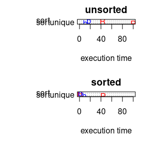

Execution time for R (R) and bit (b)

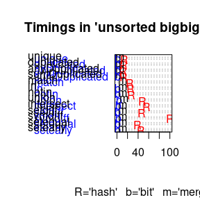

Execution time for R, bit and merge relative to most expensive R in ‘unsorted bigbig’ scenario

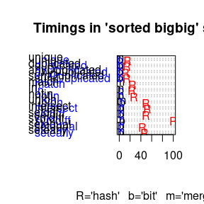

Execution time for R, bit and merge in ‘sorted bigbig’ scenario

### % time for sorting

sorted data relative to R’s sort

|  | small | big |
| --- | --- | --- |
| sort | 136.0 | 266.7 |
| sortunique | 100.2 | 20.5 |

unsorted data relative to R’s sort

|  | small | big |
| --- | --- | --- |
| sort | 30.6 | 40.5 |
| sortunique | 19.6 | 10.9 |

### % time for unique

sorted data relative to R

|  | small | big |
| --- | --- | --- |
| bit | 163.9 | 12.1 |
| merge | 30.8 | 4.2 |
| sort | 0.0 | 0.0 |

unsorted data relative to R

|  | small | big |
| --- | --- | --- |
| bit | 152.8 | 13.6 |
| merge | 184.6 | 40.3 |
| sort | 156.8 | 37.0 |

### % time for duplicated

sorted data relative to R

|  | small | big |
| --- | --- | --- |
| bit | 286.7 | 11.8 |
| merge | 24.3 | 3.6 |
| sort | 0.0 | 0.0 |

unsorted data relative to R

|  | small | big |
| --- | --- | --- |
| bit | 294.5 | 9.4 |
| merge | 215.0 | 42.7 |
| sort | 189.7 | 39.9 |

### % time for anyDuplicated

sorted data relative to R

|  | small | big |
| --- | --- | --- |
| bit | 189.6 | 13.6 |
| merge | 19.9 | 2.4 |
| sort | 0.0 | 0.0 |

unsorted data relative to R

|  | small | big |
| --- | --- | --- |
| bit | 149.2 | 10.3 |
| merge | 209.4 | 47.0 |
| sort | 190.2 | 45.2 |

### % time for sumDuplicated

sorted data relative to R

|  | small | big |
| --- | --- | --- |
| bit | 116.7 | 11.2 |
| merge | 14.4 | 2.9 |
| sort | 0.0 | 0.0 |

unsorted data relative to R

|  | small | big |
| --- | --- | --- |
| bit | 101.5 | 9.1 |
| merge | 145.2 | 41.5 |
| sort | 131.9 | 39.3 |

### % time for match

sorted data relative to R

|  | smallsmall | smallbig | bigsmall | bigbig |
| --- | --- | --- | --- | --- |
| bit | NA | NA | NA | NA |
| merge | 31.8 | 0 | 11.4 | 3.8 |
| sort | 0.0 | 0 | 0.0 | 0.0 |

unsorted data relative to R

|  | smallsmall | smallbig | bigsmall | bigbig |
| --- | --- | --- | --- | --- |
| bit | NA | NA | NA | NA |
| merge | 325.1 | 43.9 | 74.4 | 43.5 |
| sort | 293.4 | 43.8 | 66.9 | 40.9 |

### % time for in

sorted data relative to R

|  | smallsmall | smallbig | bigsmall | bigbig |
| --- | --- | --- | --- | --- |
| bit | 187.7 | 2.6 | 6.5 | 10.3 |
| merge | 25.1 | 0.0 | 9.4 | 3.5 |
| sort | 0.0 | 0.0 | 0.0 | 0.0 |

unsorted data relative to R

|  | smallsmall | smallbig | bigsmall | bigbig |
| --- | --- | --- | --- | --- |
| bit | 216.8 | 2.1 | 4.5 | 6.6 |
| merge | 285.0 | 43.3 | 64.8 | 41.7 |
| sort | 259.3 | 43.3 | 58.4 | 39.5 |

### % time for notin

sorted data relative to R

|  | smallsmall | smallbig | bigsmall | bigbig |
| --- | --- | --- | --- | --- |
| bit | 285.8 | 2.6 | 5.8 | 9.3 |
| merge | 20.0 | 0.0 | 8.3 | 3.1 |
| sort | 0.0 | 0.0 | 0.0 | 0.0 |

unsorted data relative to R

|  | smallsmall | smallbig | bigsmall | bigbig |
| --- | --- | --- | --- | --- |
| bit | 297.6 | 3.0 | 4.5 | 6.4 |
| merge | 243.2 | 43.8 | 58.7 | 39.9 |
| sort | 222.2 | 43.8 | 52.8 | 37.7 |

### % time for union

sorted data relative to R

|  | smallsmall | smallbig | bigsmall | bigbig |
| --- | --- | --- | --- | --- |
| bit | 37.4 | 13.0 | 14.2 | 10.5 |
| merge | 25.2 | 7.9 | 8.7 | 7.8 |
| sort | 0.0 | 0.0 | 0.0 | 0.0 |

unsorted data relative to R

|  | smallsmall | smallbig | bigsmall | bigbig |
| --- | --- | --- | --- | --- |
| bit | 42.4 | 10.6 | 10.7 | 7.9 |
| merge | 84.0 | 25.8 | 26.1 | 26.5 |
| sort | 56.4 | 19.6 | 19.8 | 20.8 |

### % time for intersect

sorted data relative to R

|  | smallsmall | smallbig | bigsmall | bigbig |
| --- | --- | --- | --- | --- |
| bit | 35.8 | 2.8 | 3.4 | 5.8 |
| merge | 10.5 | 0.0 | 0.0 | 2.7 |
| sort | 0.0 | 0.0 | 0.0 | 0.0 |

unsorted data relative to R

|  | smallsmall | smallbig | bigsmall | bigbig |
| --- | --- | --- | --- | --- |
| bit | 29.8 | 2.2 | 2.6 | 4.7 |
| merge | 59.4 | 19.9 | 23.2 | 19.8 |
| sort | 50.1 | 19.9 | 23.2 | 18.0 |

### % time for setdiff

sorted data relative to R

|  | smallsmall | smallbig | bigsmall | bigbig |
| --- | --- | --- | --- | --- |
| bit | 32.8 | 1.7 | 15.7 | 4.9 |
| merge | 8.7 | 0.0 | 9.4 | 3.1 |
| sort | 0.0 | 0.0 | 0.0 | 0.0 |

unsorted data relative to R

|  | smallsmall | smallbig | bigsmall | bigbig |
| --- | --- | --- | --- | --- |
| bit | 23.8 | 0.9 | 12.4 | 3.6 |
| merge | 61.8 | 19.9 | 29.2 | 23.5 |
| sort | 54.3 | 19.9 | 22.0 | 21.2 |

### % time for symdiff

sorted data relative to R

|  | smallsmall | smallbig | bigsmall | bigbig |
| --- | --- | --- | --- | --- |
| bit | 21.1 | 7.2 | 6.8 | 4.9 |
| merge | 3.6 | 3.5 | 3.3 | 1.6 |
| sort | 0.0 | 0.0 | 0.0 | 0.0 |

unsorted data relative to R

|  | smallsmall | smallbig | bigsmall | bigbig |
| --- | --- | --- | --- | --- |
| bit | 18.5 | 5.6 | 5.4 | 3.4 |
| merge | 25.6 | 11.2 | 10.7 | 11.2 |
| sort | 22.0 | 8.5 | 8.1 | 10.1 |

### % time for setequal

sorted data relative to R

|  | smallsmall | smallbig | bigsmall | bigbig |
| --- | --- | --- | --- | --- |
| bit | 61.2 | 61 | 6.6 | 7 |
| merge | 16.6 | 14 | 4.0 | 4 |
| sort | 0.0 | 0 | 0.0 | 0 |

unsorted data relative to R

|  | smallsmall | smallbig | bigsmall | bigbig |
| --- | --- | --- | --- | --- |
| bit | 65.2 | 62.0 | 5.0 | 5.1 |
| merge | 98.9 | 29274.9 | 15.9 | 28.9 |
| sort | 82.5 | 29260.6 | 12.6 | 25.7 |

### % time for setearly

sorted data relative to R

|  | smallsmall | smallbig | bigsmall | bigbig |
| --- | --- | --- | --- | --- |
| bit | 63.8 | 2.4 | 6.7 | 6.7 |
| merge | 16.1 | 0.0 | 0.1 | 2.8 |
| sort | 0.0 | 0.0 | 0.0 | 0.0 |

unsorted data relative to R

|  | smallsmall | smallbig | bigsmall | bigbig |
| --- | --- | --- | --- | --- |
| bit | 62.9 | 1.7 | 4.3 | 4.5 |
| merge | 98.3 | 26.2 | 65.7 | 23.9 |
| sort | 80.9 | 26.2 | 65.6 | 21.8 |